# Google Data Analytics Capstone - Case Study 1

Sumeet Johal

2023-02-23

## ASK

#### **Scenario**

You are a junior data analyst working in the marketing analyst team at Cyclistic, a bike-share company in Chicago. The director of marketing believes the company’s future success depends on maximizing the number of annual memberships. Therefore, your team wants to understand how casual riders and annual members use Cyclistic bikes differently. From these insights, your team will design a new marketing strategy to convert casual riders into annual members. But first, Cyclistic executives must approve your recommendations, so they must be backed up with compelling data insights and professional data visualizations.

#### **Characters and teams**

- **Cyclistic:** A bike-share program that features more than 5,800 bicycles and 600 docking stations. Cyclistic sets itself apart by also offering reclining bikes, hand tricycles, and cargo bikes, making bike-share more inclusive to people with disabilities and riders who can’t use a standard two-wheeled bike. The majority of riders opt for traditional bikes; about 8% of riders use the assistive options. Cyclistic users are more likely to ride for leisure, but about 30% use them to commute to work each day.
- **Lily Moreno:** The director of marketing and your manager. Moreno is responsible for the development of campaigns and initiatives to promote the bike-share program. These may include email, social media, and other channels.
- **Cyclistic marketing analytics team:** A team of data analysts who are responsible for collecting, analyzing, and reporting data that helps guide Cyclistic marketing strategy. You joined this team six months ago and have been busy learning about Cyclistic’s mission and business goals — as well as how you, as a junior data analyst, can help Cyclistic achieve them.
- Cyclistic executive team: The notoriously detail-oriented executive team will decide whether to approve the recommended marketing program.

#### **Guiding Questions:**

- **What is the problem you are trying to solve?**

  Determine what sets casual and member rides apart, and how to create a marketing strategy to convert casual users to members.
- **How can your insights drive business decisions?**

  They can help identify trends that show benefits for being members, and let the marketing team use this in their campaigns.
- **Clear statement of the business task**

  Understand how casual and member riders differ to help design marketing strategies aimed at converting casual riders into annual members.

## Prepare

#### **Guiding questions**

- **Where is your data located?**

  On kaggle as a dataset named “tripdata_2022”. Also available from original source [here](https://divvy-tripdata.s3.amazonaws.com/index.html) and license available [here](https://ride.divvybikes.com/data-license-agreement).
- **How is the data organized?**

  The data is in 12 csv files, one for each month of the year 2022.
- **Are there issues with bias or credibility in this data? Does your data ROCCC?**

  There is low chances of bias since the data is provided by the company itself and they have good credibility, the data also meets ROCCC since it is first party data from the previous calendar year.
- **How are you addressing licensing, privacy, security, and accessibility?**

  The data is publicly available and covered by the company’s license, both of which are included above.
- **How did you verify the data’s integrity?**

  It allows us to find trends between casual and members, and also see what sets them apart.
- **Are there any problems with the data?**

## Process

#### **Guiding questions**

- **What tools are you choosing and why?**

  I am using R studio since the dataset is too big for spreadsheets and I will also be able to clean,analyze and create graphs for the data in the same software.
- **Have you ensured your data’s integrity?**

  I made sure to check that the format of the coloumns stayed consistent through the cleaning process.
- **What steps have you taken to ensure that your data is clean?**

  All data cleaning steps are shown along with what they were used for.
- **Have you documented your cleaning process so you can review and share those results?**

  Yes, the process is documented in the file.

## Analysis

### Code

#### Load packages

```r
library(tidyverse)
library(janitor)
library(lubridate)
```

```r
library(ggplot2)
library(dplyr)
library(tidyr)
```

#### Importing csv files

```r
tripdata_202201 <- read.csv("E:/Analytics/Cyclistic/202201-divvy-tripdata.csv")
tripdata_202202 <- read.csv("E:/Analytics/Cyclistic/202202-divvy-tripdata.csv")
tripdata_202203 <- read.csv("E:/Analytics/Cyclistic/202203-divvy-tripdata.csv")
tripdata_202204 <- read.csv("E:/Analytics/Cyclistic/202204-divvy-tripdata.csv")
tripdata_202205 <- read.csv("E:/Analytics/Cyclistic/202205-divvy-tripdata.csv")
tripdata_202206 <- read.csv("E:/Analytics/Cyclistic/202206-divvy-tripdata.csv")
tripdata_202207 <- read.csv("E:/Analytics/Cyclistic/202207-divvy-tripdata.csv")
tripdata_202208 <- read.csv("E:/Analytics/Cyclistic/202208-divvy-tripdata.csv")
tripdata_202209 <- read.csv("E:/Analytics/Cyclistic/202209-divvy-tripdata.csv")
tripdata_202210 <- read.csv("E:/Analytics/Cyclistic/202210-divvy-tripdata.csv")
tripdata_202211 <- read.csv("E:/Analytics/Cyclistic/202211-divvy-tripdata.csv")
tripdata_202212 <- read.csv("E:/Analytics/Cyclistic/202212-divvy-tripdata.csv")
```

#### Examining datasets

```r
str(tripdata_202201)
```

```
## 'data.frame':    103770 obs. of  13 variables:
##  $ ride_id           : chr  "C2F7DD78E82EC875" "A6CF8980A652D272" "BD0F91DFF741C66D" "CBB80ED419105406" ...
##  $ rideable_type     : chr  "electric_bike" "electric_bike" "classic_bike" "classic_bike" ...
##  $ started_at        : chr  "2022-01-13 11:59:47" "2022-01-10 08:41:56" "2022-01-25 04:53:40" "2022-01-04 00:18:04" ...
##  $ ended_at          : chr  "2022-01-13 12:02:44" "2022-01-10 08:46:17" "2022-01-25 04:58:01" "2022-01-04 00:33:00" ...
##  $ start_station_name: chr  "Glenwood Ave & Touhy Ave" "Glenwood Ave & Touhy Ave" "Sheffield Ave & Fullerton Ave" "Clark St & Bryn Mawr Ave" ...
##  $ start_station_id  : chr  "525" "525" "TA1306000016" "KA1504000151" ...
##  $ end_station_name  : chr  "Clark St & Touhy Ave" "Clark St & Touhy Ave" "Greenview Ave & Fullerton Ave" "Paulina St & Montrose Ave" ...
##  $ end_station_id    : chr  "RP-007" "RP-007" "TA1307000001" "TA1309000021" ...
##  $ start_lat         : num  42 42 41.9 42 41.9 ...
##  $ start_lng         : num  -87.7 -87.7 -87.7 -87.7 -87.6 ...
##  $ end_lat           : num  42 42 41.9 42 41.9 ...
##  $ end_lng           : num  -87.7 -87.7 -87.7 -87.7 -87.6 ...
##  $ member_casual     : chr  "casual" "casual" "member" "casual" ...
```

```r
str(tripdata_202202)
```

```
## 'data.frame':    115609 obs. of  13 variables:
##  $ ride_id           : chr  "E1E065E7ED285C02" "1602DCDC5B30FFE3" "BE7DD2AF4B55C4AF" "A1789BDF844412BE" ...
##  $ rideable_type     : chr  "classic_bike" "classic_bike" "classic_bike" "classic_bike" ...
##  $ started_at        : chr  "2022-02-19 18:08:41" "2022-02-20 17:41:30" "2022-02-25 18:55:56" "2022-02-14 11:57:03" ...
##  $ ended_at          : chr  "2022-02-19 18:23:56" "2022-02-20 17:45:56" "2022-02-25 19:09:34" "2022-02-14 12:04:00" ...
##  $ start_station_name: chr  "State St & Randolph St" "Halsted St & Wrightwood Ave" "State St & Randolph St" "Southport Ave & Waveland Ave" ...
##  $ start_station_id  : chr  "TA1305000029" "TA1309000061" "TA1305000029" "13235" ...
##  $ end_station_name  : chr  "Clark St & Lincoln Ave" "Southport Ave & Wrightwood Ave" "Canal St & Adams St" "Broadway & Sheridan Rd" ...
##  $ end_station_id    : chr  "13179" "TA1307000113" "13011" "13323" ...
##  $ start_lat         : num  41.9 41.9 41.9 41.9 41.9 ...
##  $ start_lng         : num  -87.6 -87.6 -87.6 -87.7 -87.6 ...
##  $ end_lat           : num  41.9 41.9 41.9 42 41.9 ...
##  $ end_lng           : num  -87.6 -87.7 -87.6 -87.6 -87.6 ...
##  $ member_casual     : chr  "member" "member" "member" "member" ...
```

```r
str(tripdata_202203)
```

```
## 'data.frame':    284042 obs. of  13 variables:
##  $ ride_id           : chr  "47EC0A7F82E65D52" "8494861979B0F477" "EFE527AF80B66109" "9F446FD9DEE3F389" ...
##  $ rideable_type     : chr  "classic_bike" "electric_bike" "classic_bike" "classic_bike" ...
##  $ started_at        : chr  "2022-03-21 13:45:01" "2022-03-16 09:37:16" "2022-03-23 19:52:02" "2022-03-01 19:12:26" ...
##  $ ended_at          : chr  "2022-03-21 13:51:18" "2022-03-16 09:43:34" "2022-03-23 19:54:48" "2022-03-01 19:22:14" ...
##  $ start_station_name: chr  "Wabash Ave & Wacker Pl" "Michigan Ave & Oak St" "Broadway & Berwyn Ave" "Wabash Ave & Wacker Pl" ...
##  $ start_station_id  : chr  "TA1307000131" "13042" "13109" "TA1307000131" ...
##  $ end_station_name  : chr  "Kingsbury St & Kinzie St" "Orleans St & Chestnut St (NEXT Apts)" "Broadway & Ridge Ave" "Franklin St & Jackson Blvd" ...
##  $ end_station_id    : chr  "KA1503000043" "620" "15578" "TA1305000025" ...
##  $ start_lat         : num  41.9 41.9 42 41.9 41.9 ...
##  $ start_lng         : num  -87.6 -87.6 -87.7 -87.6 -87.6 ...
##  $ end_lat           : num  41.9 41.9 42 41.9 41.9 ...
##  $ end_lng           : num  -87.6 -87.6 -87.7 -87.6 -87.7 ...
##  $ member_casual     : chr  "member" "member" "member" "member" ...
```

```r
str(tripdata_202204)
```

```
## 'data.frame':    371249 obs. of  13 variables:
##  $ ride_id           : chr  "3564070EEFD12711" "0B820C7FCF22F489" "89EEEE32293F07FF" "84D4751AEB31888D" ...
##  $ rideable_type     : chr  "electric_bike" "classic_bike" "classic_bike" "classic_bike" ...
##  $ started_at        : chr  "2022-04-06 17:42:48" "2022-04-24 19:23:07" "2022-04-20 19:29:08" "2022-04-22 21:14:06" ...
##  $ ended_at          : chr  "2022-04-06 17:54:36" "2022-04-24 19:43:17" "2022-04-20 19:35:16" "2022-04-22 21:23:29" ...
##  $ start_station_name: chr  "Paulina St & Howard St" "Wentworth Ave & Cermak Rd" "Halsted St & Polk St" "Wentworth Ave & Cermak Rd" ...
##  $ start_station_id  : chr  "515" "13075" "TA1307000121" "13075" ...
##  $ end_station_name  : chr  "University Library (NU)" "Green St & Madison St" "Green St & Madison St" "Delano Ct & Roosevelt Rd" ...
##  $ end_station_id    : chr  "605" "TA1307000120" "TA1307000120" "KA1706005007" ...
##  $ start_lat         : num  42 41.9 41.9 41.9 41.9 ...
##  $ start_lng         : num  -87.7 -87.6 -87.6 -87.6 -87.6 ...
##  $ end_lat           : num  42.1 41.9 41.9 41.9 41.9 ...
##  $ end_lng           : num  -87.7 -87.6 -87.6 -87.6 -87.6 ...
##  $ member_casual     : chr  "member" "member" "member" "casual" ...
```

```r
str(tripdata_202205)
```

```
## 'data.frame':    634858 obs. of  13 variables:
##  $ ride_id           : chr  "EC2DE40644C6B0F4" "1C31AD03897EE385" "1542FBEC830415CF" "6FF59852924528F8" ...
##  $ rideable_type     : chr  "classic_bike" "classic_bike" "classic_bike" "classic_bike" ...
##  $ started_at        : chr  "2022-05-23 23:06:58" "2022-05-11 08:53:28" "2022-05-26 18:36:28" "2022-05-10 07:30:07" ...
##  $ ended_at          : chr  "2022-05-23 23:40:19" "2022-05-11 09:31:22" "2022-05-26 18:58:18" "2022-05-10 07:38:49" ...
##  $ start_station_name: chr  "Wabash Ave & Grand Ave" "DuSable Lake Shore Dr & Monroe St" "Clinton St & Madison St" "Clinton St & Madison St" ...
##  $ start_station_id  : chr  "TA1307000117" "13300" "TA1305000032" "TA1305000032" ...
##  $ end_station_name  : chr  "Halsted St & Roscoe St" "Field Blvd & South Water St" "Wood St & Milwaukee Ave" "Clark St & Randolph St" ...
##  $ end_station_id    : chr  "TA1309000025" "15534" "13221" "TA1305000030" ...
##  $ start_lat         : num  41.9 41.9 41.9 41.9 41.9 ...
##  $ start_lng         : num  -87.6 -87.6 -87.6 -87.6 -87.6 ...
##  $ end_lat           : num  41.9 41.9 41.9 41.9 41.9 ...
##  $ end_lng           : num  -87.6 -87.6 -87.7 -87.6 -87.7 ...
##  $ member_casual     : chr  "member" "member" "member" "member" ...
```

```r
str(tripdata_202206)
```

```
## 'data.frame':    769204 obs. of  13 variables:
##  $ ride_id           : chr  "600CFD130D0FD2A4" "F5E6B5C1682C6464" "B6EB6D27BAD771D2" "C9C320375DE1D5C6" ...
##  $ rideable_type     : chr  "electric_bike" "electric_bike" "electric_bike" "electric_bike" ...
##  $ started_at        : chr  "2022-06-30 17:27:53" "2022-06-30 18:39:52" "2022-06-30 11:49:25" "2022-06-30 11:15:25" ...
##  $ ended_at          : chr  "2022-06-30 17:35:15" "2022-06-30 18:47:28" "2022-06-30 12:02:54" "2022-06-30 11:19:43" ...
##  $ start_station_name: chr  "" "" "" "" ...
##  $ start_station_id  : chr  "" "" "" "" ...
##  $ end_station_name  : chr  "" "" "" "" ...
##  $ end_station_id    : chr  "" "" "" "" ...
##  $ start_lat         : num  41.9 41.9 41.9 41.8 41.9 ...
##  $ start_lng         : num  -87.6 -87.6 -87.7 -87.7 -87.6 ...
##  $ end_lat           : num  41.9 41.9 41.9 41.8 41.9 ...
##  $ end_lng           : num  -87.6 -87.6 -87.6 -87.7 -87.6 ...
##  $ member_casual     : chr  "casual" "casual" "casual" "casual" ...
```

```r
str(tripdata_202207)
```

```
## 'data.frame':    823488 obs. of  13 variables:
##  $ ride_id           : chr  "954144C2F67B1932" "292E027607D218B6" "57765852588AD6E0" "B5B6BE44314590E6" ...
##  $ rideable_type     : chr  "classic_bike" "classic_bike" "classic_bike" "classic_bike" ...
##  $ started_at        : chr  "2022-07-05 08:12:47" "2022-07-26 12:53:38" "2022-07-03 13:58:49" "2022-07-31 17:44:21" ...
##  $ ended_at          : chr  "2022-07-05 08:24:32" "2022-07-26 12:55:31" "2022-07-03 14:06:32" "2022-07-31 18:42:50" ...
##  $ start_station_name: chr  "Ashland Ave & Blackhawk St" "Buckingham Fountain (Temp)" "Buckingham Fountain (Temp)" "Buckingham Fountain (Temp)" ...
##  $ start_station_id  : chr  "13224" "15541" "15541" "15541" ...
##  $ end_station_name  : chr  "Kingsbury St & Kinzie St" "Michigan Ave & 8th St" "Michigan Ave & 8th St" "Woodlawn Ave & 55th St" ...
##  $ end_station_id    : chr  "KA1503000043" "623" "623" "TA1307000164" ...
##  $ start_lat         : num  41.9 41.9 41.9 41.9 41.9 ...
##  $ start_lng         : num  -87.7 -87.6 -87.6 -87.6 -87.6 ...
##  $ end_lat           : num  41.9 41.9 41.9 41.8 41.9 ...
##  $ end_lng           : num  -87.6 -87.6 -87.6 -87.6 -87.7 ...
##  $ member_casual     : chr  "member" "casual" "casual" "casual" ...
```

```r
str(tripdata_202208)
```

```
## 'data.frame':    785932 obs. of  13 variables:
##  $ ride_id           : chr  "550CF7EFEAE0C618" "DAD198F405F9C5F5" "E6F2BC47B65CB7FD" "F597830181C2E13C" ...
##  $ rideable_type     : chr  "electric_bike" "electric_bike" "electric_bike" "electric_bike" ...
##  $ started_at        : chr  "2022-08-07 21:34:15" "2022-08-08 14:39:21" "2022-08-08 15:29:50" "2022-08-08 02:43:50" ...
##  $ ended_at          : chr  "2022-08-07 21:41:46" "2022-08-08 14:53:23" "2022-08-08 15:40:34" "2022-08-08 02:58:53" ...
##  $ start_station_name: chr  "" "" "" "" ...
##  $ start_station_id  : chr  "" "" "" "" ...
##  $ end_station_name  : chr  "" "" "" "" ...
##  $ end_station_id    : chr  "" "" "" "" ...
##  $ start_lat         : num  41.9 41.9 42 41.9 41.9 ...
##  $ start_lng         : num  -87.7 -87.6 -87.7 -87.7 -87.7 ...
##  $ end_lat           : num  41.9 41.9 42 42 41.8 ...
##  $ end_lng           : num  -87.7 -87.6 -87.7 -87.7 -87.7 ...
##  $ member_casual     : chr  "casual" "casual" "casual" "casual" ...
```

```r
str(tripdata_202209)
```

```
## 'data.frame':    701339 obs. of  13 variables:
##  $ ride_id           : chr  "5156990AC19CA285" "E12D4A16BF51C274" "A02B53CD7DB72DD7" "C82E05FEE872DF11" ...
##  $ rideable_type     : chr  "electric_bike" "electric_bike" "electric_bike" "electric_bike" ...
##  $ started_at        : chr  "2022-09-01 08:36:22" "2022-09-01 17:11:29" "2022-09-01 17:15:50" "2022-09-01 09:00:28" ...
##  $ ended_at          : chr  "2022-09-01 08:39:05" "2022-09-01 17:14:45" "2022-09-01 17:16:12" "2022-09-01 09:10:32" ...
##  $ start_station_name: chr  "" "" "" "" ...
##  $ start_station_id  : chr  "" "" "" "" ...
##  $ end_station_name  : chr  "California Ave & Milwaukee Ave" "" "" "" ...
##  $ end_station_id    : chr  "13084" "" "" "" ...
##  $ start_lat         : num  41.9 41.9 41.9 41.9 41.9 ...
##  $ start_lng         : num  -87.7 -87.6 -87.6 -87.7 -87.7 ...
##  $ end_lat           : num  41.9 41.9 41.9 41.9 41.9 ...
##  $ end_lng           : num  -87.7 -87.6 -87.6 -87.7 -87.7 ...
##  $ member_casual     : chr  "casual" "casual" "casual" "casual" ...
```

```r
str(tripdata_202210)
```

```
## 'data.frame':    558685 obs. of  13 variables:
##  $ ride_id           : chr  "A50255C1E17942AB" "DB692A70BD2DD4E3" "3C02727AAF60F873" "47E653FDC2D99236" ...
##  $ rideable_type     : chr  "classic_bike" "electric_bike" "electric_bike" "electric_bike" ...
##  $ started_at        : chr  "2022-10-14 17:13:30" "2022-10-01 16:29:26" "2022-10-19 18:55:40" "2022-10-31 07:52:36" ...
##  $ ended_at          : chr  "2022-10-14 17:19:39" "2022-10-01 16:49:06" "2022-10-19 19:03:30" "2022-10-31 07:58:49" ...
##  $ start_station_name: chr  "Noble St & Milwaukee Ave" "Damen Ave & Charleston St" "Hoyne Ave & Balmoral Ave" "Rush St & Cedar St" ...
##  $ start_station_id  : chr  "13290" "13288" "655" "KA1504000133" ...
##  $ end_station_name  : chr  "Larrabee St & Division St" "Damen Ave & Cullerton St" "Western Ave & Leland Ave" "Orleans St & Chestnut St (NEXT Apts)" ...
##  $ end_station_id    : chr  "KA1504000079" "13089" "TA1307000140" "620" ...
##  $ start_lat         : num  41.9 41.9 42 41.9 41.9 ...
##  $ start_lng         : num  -87.7 -87.7 -87.7 -87.6 -87.6 ...
##  $ end_lat           : num  41.9 41.9 42 41.9 41.9 ...
##  $ end_lng           : num  -87.6 -87.7 -87.7 -87.6 -87.6 ...
##  $ member_casual     : chr  "member" "casual" "member" "member" ...
```

```r
str(tripdata_202211)
```

```
## 'data.frame':    337735 obs. of  13 variables:
##  $ ride_id           : chr  "BCC66FC6FAB27CC7" "772AB67E902C180F" "585EAD07FDEC0152" "91C4E7ED3C262FF9" ...
##  $ rideable_type     : chr  "electric_bike" "classic_bike" "classic_bike" "classic_bike" ...
##  $ started_at        : chr  "2022-11-10 06:21:55" "2022-11-04 07:31:55" "2022-11-21 17:20:29" "2022-11-25 17:29:34" ...
##  $ ended_at          : chr  "2022-11-10 06:31:27" "2022-11-04 07:46:25" "2022-11-21 17:34:36" "2022-11-25 17:45:15" ...
##  $ start_station_name: chr  "Canal St & Adams St" "Canal St & Adams St" "Indiana Ave & Roosevelt Rd" "Indiana Ave & Roosevelt Rd" ...
##  $ start_station_id  : chr  "13011" "13011" "SL-005" "SL-005" ...
##  $ end_station_name  : chr  "St. Clair St & Erie St" "St. Clair St & Erie St" "St. Clair St & Erie St" "St. Clair St & Erie St" ...
##  $ end_station_id    : chr  "13016" "13016" "13016" "13016" ...
##  $ start_lat         : num  41.9 41.9 41.9 41.9 41.9 ...
##  $ start_lng         : num  -87.6 -87.6 -87.6 -87.6 -87.6 ...
##  $ end_lat           : num  41.9 41.9 41.9 41.9 41.9 ...
##  $ end_lng           : num  -87.6 -87.6 -87.6 -87.6 -87.6 ...
##  $ member_casual     : chr  "member" "member" "member" "member" ...
```

```r
str(tripdata_202212)
```

```
## 'data.frame':    181806 obs. of  13 variables:
##  $ ride_id           : chr  "65DBD2F447EC51C2" "0C201AA7EA0EA1AD" "E0B148CCB358A49D" "54C5775D2B7C9188" ...
##  $ rideable_type     : chr  "electric_bike" "classic_bike" "electric_bike" "classic_bike" ...
##  $ started_at        : chr  "2022-12-05 10:47:18" "2022-12-18 06:42:33" "2022-12-13 08:47:45" "2022-12-13 18:50:47" ...
##  $ ended_at          : chr  "2022-12-05 10:56:34" "2022-12-18 07:08:44" "2022-12-13 08:59:51" "2022-12-13 19:19:48" ...
##  $ start_station_name: chr  "Clifton Ave & Armitage Ave" "Broadway & Belmont Ave" "Sangamon St & Lake St" "Shields Ave & 31st St" ...
##  $ start_station_id  : chr  "TA1307000163" "13277" "TA1306000015" "KA1503000038" ...
##  $ end_station_name  : chr  "Sedgwick St & Webster Ave" "Sedgwick St & Webster Ave" "St. Clair St & Erie St" "Damen Ave & Madison St" ...
##  $ end_station_id    : chr  "13191" "13191" "13016" "13134" ...
##  $ start_lat         : num  41.9 41.9 41.9 41.8 41.9 ...
##  $ start_lng         : num  -87.7 -87.6 -87.7 -87.6 -87.7 ...
##  $ end_lat           : num  41.9 41.9 41.9 41.9 41.9 ...
##  $ end_lng           : num  -87.6 -87.6 -87.6 -87.7 -87.7 ...
##  $ member_casual     : chr  "member" "casual" "member" "member" ...
```

#### All files have columns in same formats, combining into one file

```r
tripdata_2022 <- rbind(
                       tripdata_202201,
                       tripdata_202202,
                       tripdata_202203,
                       tripdata_202204,
                       tripdata_202205,
                       tripdata_202206,
                       tripdata_202207,
                       tripdata_202208,
                       tripdata_202209,
                       tripdata_202210,
                       tripdata_202211,
                       tripdata_202212
                       )
```

#### Confirming total number of rows for individual files

```r
rowtotal <- sum(
                nrow(tripdata_202201),
                nrow(tripdata_202202),
                nrow(tripdata_202203),
                nrow(tripdata_202204),
                nrow(tripdata_202205),
                nrow(tripdata_202206),
                nrow(tripdata_202207),
                nrow(tripdata_202208),
                nrow(tripdata_202209),
                nrow(tripdata_202210),
                nrow(tripdata_202211),
                nrow(tripdata_202212)
                )
print(rowtotal)
```

```
## [1] 5667717
```

#### Confirming total number of rows for combined dataset

```r
print(nrow(tripdata_2022))
```

```
## [1] 5667717
```

#### Examining combined dataset

```r
str(tripdata_2022)
```

```
## 'data.frame':    5667717 obs. of  13 variables:
##  $ ride_id           : chr  "C2F7DD78E82EC875" "A6CF8980A652D272" "BD0F91DFF741C66D" "CBB80ED419105406" ...
##  $ rideable_type     : chr  "electric_bike" "electric_bike" "classic_bike" "classic_bike" ...
##  $ started_at        : chr  "2022-01-13 11:59:47" "2022-01-10 08:41:56" "2022-01-25 04:53:40" "2022-01-04 00:18:04" ...
##  $ ended_at          : chr  "2022-01-13 12:02:44" "2022-01-10 08:46:17" "2022-01-25 04:58:01" "2022-01-04 00:33:00" ...
##  $ start_station_name: chr  "Glenwood Ave & Touhy Ave" "Glenwood Ave & Touhy Ave" "Sheffield Ave & Fullerton Ave" "Clark St & Bryn Mawr Ave" ...
##  $ start_station_id  : chr  "525" "525" "TA1306000016" "KA1504000151" ...
##  $ end_station_name  : chr  "Clark St & Touhy Ave" "Clark St & Touhy Ave" "Greenview Ave & Fullerton Ave" "Paulina St & Montrose Ave" ...
##  $ end_station_id    : chr  "RP-007" "RP-007" "TA1307000001" "TA1309000021" ...
##  $ start_lat         : num  42 42 41.9 42 41.9 ...
##  $ start_lng         : num  -87.7 -87.7 -87.7 -87.7 -87.6 ...
##  $ end_lat           : num  42 42 41.9 42 41.9 ...
##  $ end_lng           : num  -87.7 -87.7 -87.7 -87.7 -87.6 ...
##  $ member_casual     : chr  "casual" "casual" "member" "casual" ...
```

```r
head(tripdata_2022)
```

```
##            ride_id rideable_type          started_at            ended_at
## 1 C2F7DD78E82EC875 electric_bike 2022-01-13 11:59:47 2022-01-13 12:02:44
## 2 A6CF8980A652D272 electric_bike 2022-01-10 08:41:56 2022-01-10 08:46:17
## 3 BD0F91DFF741C66D  classic_bike 2022-01-25 04:53:40 2022-01-25 04:58:01
## 4 CBB80ED419105406  classic_bike 2022-01-04 00:18:04 2022-01-04 00:33:00
## 5 DDC963BFDDA51EEA  classic_bike 2022-01-20 01:31:10 2022-01-20 01:37:12
## 6 A39C6F6CC0586C0B  classic_bike 2022-01-11 18:48:09 2022-01-11 18:51:31
##              start_station_name start_station_id              end_station_name
## 1      Glenwood Ave & Touhy Ave              525          Clark St & Touhy Ave
## 2      Glenwood Ave & Touhy Ave              525          Clark St & Touhy Ave
## 3 Sheffield Ave & Fullerton Ave     TA1306000016 Greenview Ave & Fullerton Ave
## 4      Clark St & Bryn Mawr Ave     KA1504000151     Paulina St & Montrose Ave
## 5   Michigan Ave & Jackson Blvd     TA1309000002        State St & Randolph St
## 6         Wood St & Chicago Ave              637       Honore St & Division St
##   end_station_id start_lat start_lng  end_lat   end_lng member_casual
## 1         RP-007  42.01280 -87.66591 42.01256 -87.67437        casual
## 2         RP-007  42.01276 -87.66597 42.01256 -87.67437        casual
## 3   TA1307000001  41.92560 -87.65371 41.92533 -87.66580        member
## 4   TA1309000021  41.98359 -87.66915 41.96151 -87.67139        casual
## 5   TA1305000029  41.87785 -87.62408 41.88462 -87.62783        member
## 6   TA1305000034  41.89563 -87.67207 41.90312 -87.67394        member
```

#### Formatting date coloumn into individual columns for date,month,day,year and day of week

```r
tripdata_2022$date <- as.Date(tripdata_2022$started_at)
tripdata_2022$month <- format(as.Date(tripdata_2022$date), "%b")
tripdata_2022$day <- format(as.Date(tripdata_2022$date), "%d")
tripdata_2022$year <- format(as.Date(tripdata_2022$date), "%Y")
tripdata_2022$day_of_week <- format(as.Date(tripdata_2022$date), "%A")
head(tripdata_2022)
```

```
##            ride_id rideable_type          started_at            ended_at
## 1 C2F7DD78E82EC875 electric_bike 2022-01-13 11:59:47 2022-01-13 12:02:44
## 2 A6CF8980A652D272 electric_bike 2022-01-10 08:41:56 2022-01-10 08:46:17
## 3 BD0F91DFF741C66D  classic_bike 2022-01-25 04:53:40 2022-01-25 04:58:01
## 4 CBB80ED419105406  classic_bike 2022-01-04 00:18:04 2022-01-04 00:33:00
## 5 DDC963BFDDA51EEA  classic_bike 2022-01-20 01:31:10 2022-01-20 01:37:12
## 6 A39C6F6CC0586C0B  classic_bike 2022-01-11 18:48:09 2022-01-11 18:51:31
##              start_station_name start_station_id              end_station_name
## 1      Glenwood Ave & Touhy Ave              525          Clark St & Touhy Ave
## 2      Glenwood Ave & Touhy Ave              525          Clark St & Touhy Ave
## 3 Sheffield Ave & Fullerton Ave     TA1306000016 Greenview Ave & Fullerton Ave
## 4      Clark St & Bryn Mawr Ave     KA1504000151     Paulina St & Montrose Ave
## 5   Michigan Ave & Jackson Blvd     TA1309000002        State St & Randolph St
## 6         Wood St & Chicago Ave              637       Honore St & Division St
##   end_station_id start_lat start_lng  end_lat   end_lng member_casual
## 1         RP-007  42.01280 -87.66591 42.01256 -87.67437        casual
## 2         RP-007  42.01276 -87.66597 42.01256 -87.67437        casual
## 3   TA1307000001  41.92560 -87.65371 41.92533 -87.66580        member
## 4   TA1309000021  41.98359 -87.66915 41.96151 -87.67139        casual
## 5   TA1305000029  41.87785 -87.62408 41.88462 -87.62783        member
## 6   TA1305000034  41.89563 -87.67207 41.90312 -87.67394        member
##         date month day year day_of_week
## 1 2022-01-13   Jan  13 2022    Thursday
## 2 2022-01-10   Jan  10 2022      Monday
## 3 2022-01-25   Jan  25 2022     Tuesday
## 4 2022-01-04   Jan  04 2022     Tuesday
## 5 2022-01-20   Jan  20 2022    Thursday
## 6 2022-01-11   Jan  11 2022     Tuesday
```

#### Removing NA

```r
drop_na(tripdata_2022)
```

#### Removing duplicates

```r
tripdata_2022_no_duplicates <- tripdata_2022[!duplicated(tripdata_2022$ride_id), ]
print(paste("removed", nrow(tripdata_2022) - nrow(tripdata_2022_no_duplicates), "duplicate rows"))
```

```
## [1] "removed 0 duplicate rows"
```

#### Creating a column to determine ride length

```r
tripdata_2022_v2 <- mutate(tripdata_2022_no_duplicates, ride_length = difftime(ended_at, started_at, units = "mins"))
str(tripdata_2022_v2)
```

```
## 'data.frame':    5667717 obs. of  19 variables:
##  $ ride_id           : chr  "C2F7DD78E82EC875" "A6CF8980A652D272" "BD0F91DFF741C66D" "CBB80ED419105406" ...
##  $ rideable_type     : chr  "electric_bike" "electric_bike" "classic_bike" "classic_bike" ...
##  $ started_at        : chr  "2022-01-13 11:59:47" "2022-01-10 08:41:56" "2022-01-25 04:53:40" "2022-01-04 00:18:04" ...
##  $ ended_at          : chr  "2022-01-13 12:02:44" "2022-01-10 08:46:17" "2022-01-25 04:58:01" "2022-01-04 00:33:00" ...
##  $ start_station_name: chr  "Glenwood Ave & Touhy Ave" "Glenwood Ave & Touhy Ave" "Sheffield Ave & Fullerton Ave" "Clark St & Bryn Mawr Ave" ...
##  $ start_station_id  : chr  "525" "525" "TA1306000016" "KA1504000151" ...
##  $ end_station_name  : chr  "Clark St & Touhy Ave" "Clark St & Touhy Ave" "Greenview Ave & Fullerton Ave" "Paulina St & Montrose Ave" ...
##  $ end_station_id    : chr  "RP-007" "RP-007" "TA1307000001" "TA1309000021" ...
##  $ start_lat         : num  42 42 41.9 42 41.9 ...
##  $ start_lng         : num  -87.7 -87.7 -87.7 -87.7 -87.6 ...
##  $ end_lat           : num  42 42 41.9 42 41.9 ...
##  $ end_lng           : num  -87.7 -87.7 -87.7 -87.7 -87.6 ...
##  $ member_casual     : chr  "casual" "casual" "member" "casual" ...
##  $ date              : Date, format: "2022-01-13" "2022-01-10" ...
##  $ month             : chr  "Jan" "Jan" "Jan" "Jan" ...
##  $ day               : chr  "13" "10" "25" "04" ...
##  $ year              : chr  "2022" "2022" "2022" "2022" ...
##  $ day_of_week       : chr  "Thursday" "Monday" "Tuesday" "Tuesday" ...
##  $ ride_length       : 'difftime' num  2.95 4.35 4.35 14.9333333333333 ...
##   ..- attr(*, "units")= chr "mins"
```

#### Filtering out rows with a ride length less than 0

```r
nrow(tripdata_2022_v2[tripdata_2022_v2$ride_length < 0,])
```

```
## [1] 100
```

```r
tripdata_2022_v3 <- tripdata_2022_v2[!tripdata_2022_v2$ride_length < 0,]
```

#### Comparing amount of members vs casual riders

```r
rider_type_total <- table(tripdata_2022_v3$member_casual)
data.frame(rider_type_total)
```

```
##     Var1    Freq
## 1 casual 2321977
## 2 member 3345640
```

#### Trip data by day of week

```r
tripdata_2022_v3$day_of_week <- ordered(tripdata_2022_v3$day_of_week,
levels = c("Monday", "Tuesday", "Wednesday", "Thursday", "Friday", "Saturday", "Sunday"))
```

```r
trip_stats <- tripdata_2022_v3 %>%
    group_by(member_casual, day_of_week) %>%
    summarise(
      average_ride_length = mean(ride_length),
      median_ride_length = median(ride_length),
      min_ride_length = min(ride_length),
      max_ride_length = max(ride_length),
      rider_type_total = n()
      )
data.frame(trip_stats)
```

```
##    member_casual day_of_week average_ride_length median_ride_length
## 1         casual      Friday       28.04443 mins     12.466667 mins
## 2         casual      Monday       29.18715 mins     12.866667 mins
## 3         casual    Saturday       32.61332 mins     14.950000 mins
## 4         casual      Sunday       34.06411 mins     15.016667 mins
## 5         casual    Thursday       25.54908 mins     11.750000 mins
## 6         casual     Tuesday       25.82264 mins     11.533333 mins
## 7         casual   Wednesday       24.75063 mins     11.433333 mins
## 8         member      Friday       12.53077 mins      8.716667 mins
## 9         member      Monday       12.27011 mins      8.450000 mins
## 10        member    Saturday       14.13966 mins      9.800000 mins
## 11        member      Sunday       14.03496 mins      9.550000 mins
## 12        member    Thursday       12.29273 mins      8.666667 mins
## 13        member     Tuesday       12.12949 mins      8.483333 mins
## 14        member   Wednesday       12.10489 mins      8.583333 mins
##    min_ride_length max_ride_length rider_type_total
## 1           0 mins  32402.967 mins           334698
## 2           0 mins  32035.450 mins           277671
## 3           0 mins  41387.250 mins           473185
## 4           0 mins  36257.800 mins           389011
## 5           0 mins  31023.500 mins           309327
## 6           0 mins  31085.850 mins           263731
## 7           0 mins  35820.633 mins           274354
## 8           0 mins   1499.967 mins           467083
## 9           0 mins   1499.950 mins           473335
## 10          0 mins   1499.950 mins           443274
## 11          0 mins   1499.950 mins           387208
## 12          0 mins   1499.950 mins           532255
## 13          0 mins   1499.950 mins           518618
## 14          0 mins   1499.950 mins           523867
```

#### Trip data by month

```r
tripdata_2022_v3 %>%
  mutate(month = factor(month, levels = month.name)) %>%
  arrange(month)
```

```r
tripdata_2022_v3$month <- ordered(tripdata_2022_v3$month,
  levels = c("Jan", "Feb", "Mar", "Apr", "May", "Jun", "Jul", "Aug", "Sep", "Oct", "Nov", "Dec"))
trip_stats_month <- tripdata_2022_v3 %>%
  group_by(month, member_casual) %>%
  summarise(
    average_ride_length = mean(ride_length),
    median_ride_length = median(ride_length),
    min_ride_length = min(ride_length),
    max_ride_length = max(ride_length),
    rider_type_total = n()
    )
data.frame(trip_stats_month)
```

```
##    month member_casual average_ride_length median_ride_length min_ride_length
## 1    Jan        casual       30.37746 mins     10.133333 mins          0 mins
## 2    Jan        member       11.98151 mins      7.483333 mins          0 mins
## 3    Feb        casual       26.70845 mins     10.900000 mins          0 mins
## 4    Feb        member       11.40553 mins      7.516667 mins          0 mins
## 5    Mar        casual       32.60516 mins     14.216667 mins          0 mins
## 6    Mar        member       11.95493 mins      8.033333 mins          0 mins
## 7    Apr        casual       29.53243 mins     13.833333 mins          0 mins
## 8    Apr        member       11.49240 mins      7.883333 mins          0 mins
## 9    May        casual       30.86972 mins     15.283333 mins          0 mins
## 10   May        member       13.36668 mins      9.383333 mins          0 mins
## 11   Jun        casual       32.09961 mins     14.350000 mins          0 mins
## 12   Jun        member       13.99927 mins     10.033333 mins          0 mins
## 13   Jul        casual       29.27885 mins     14.033333 mins          0 mins
## 14   Jul        member       13.71864 mins      9.900000 mins          0 mins
```

[output cut: 35 more lines]

#### Popular start stations

```r
popular_start_stations <- tripdata_2022_v3 %>%
  group_by(start_station_name, member_casual) %>%
  summarise(number_of_starts = n()) %>%
  filter(start_station_name != "") %>%
  arrange(- number_of_starts)
tibble(popular_start_stations)
```

```
## # A tibble: 3,094 × 3
##    start_station_name                 member_casual number_of_starts
##    <chr>                              <chr>                    <int>
##  1 Streeter Dr & Grand Ave            casual                   58094
##  2 DuSable Lake Shore Dr & Monroe St  casual                   31862
##  3 Millennium Park                    casual                   25529
##  4 Michigan Ave & Oak St              casual                   25265
##  5 Kingsbury St & Kinzie St           member                   24937
##  6 DuSable Lake Shore Dr & North Blvd casual                   23657
##  7 Clark St & Elm St                  member                   22040
##  8 Wells St & Concord Ln              member                   21298
##  9 Shedd Aquarium                     casual                   20265
## 10 University Ave & 57th St           member                   19953
## # … with 3,084 more rows
```

#### **Findings**

- There were more member riders (3 345 640) than casual riders (2 321 977) in 2022.
- The most popular day for members was Thursday with 532 255 rides.
- The most popular day for casuals was Saturday with 473 185 rides.
- The most popular month for members was August with 427 000 rides.
- The most popular month for casuals was July with 406 046 rides.
- The most popular station for members was Kingsbury St & Kinzie St with 24 937 rides.
- The most popular station for casuals was Streeter Dr & Grand Ave with 58 094 rides.

## Share

#### **Guiding questions**

- **Were you able to answer the question of how annual members and casual riders use Cyclistic bikes differently?**

  Yes, several trends and differences in how members and casual riders use bikes differently emerged.
- **What story does your data tell?**

  The data tells us that there are more member rides but that the casuals have longer average trip durations.
- **How do your findings relate to your original question?**

  They will allow a marketing strategy to be made for casuals that will highlight benefits of becoming a member since they are already on average using the bike for longer durations.
- **Who is your audience? What is the best way to communicate with them?**

  The key stakeholders identified before. the best way to communicate the findings would be through a rreport or prsentation of the findings.
- **Can data visualization help you share your findings?**

  Yes, graphs can quickly convey the results of the data analysis.
- **Is your presentation accessible to your audience?**

  This notebook is available on Kaggle.

### Graphs for day of week

```r
tripdata_2022_v3$day_of_week <- ordered(tripdata_2022_v3$day_of_week,
levels = c("Monday", "Tuesday", "Wednesday", "Thursday", "Friday", "Saturday", "Sunday"))
graph_data_weekly <- tripdata_2022_v3 %>%
  group_by(member_casual, day_of_week) %>%
  summarise(number_of_rides = n(), average_duration = mean(ride_length)) %>%
  arrange(member_casual, day_of_week)
```

#### Average ride length for day of week

```
## Defaulting to continuous.
```

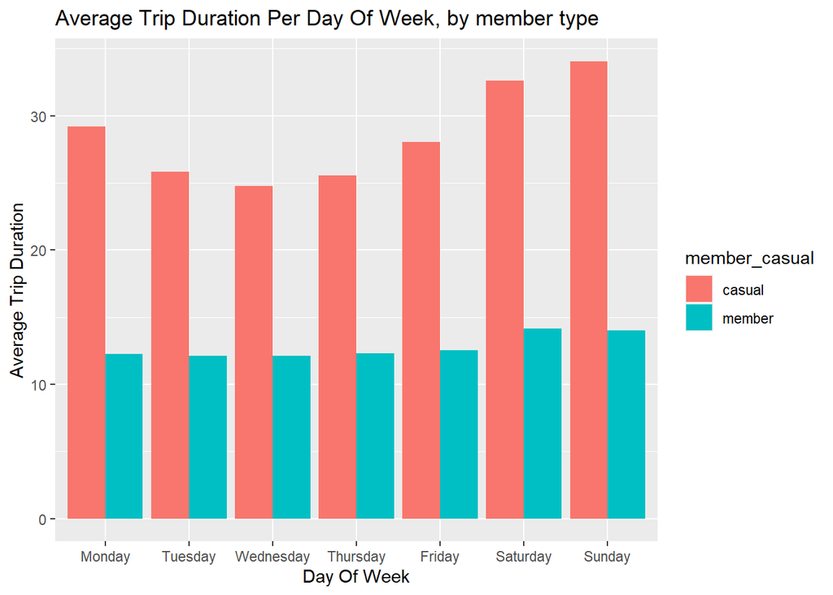

```r
ggplot(graph_data_weekly, aes(x = day_of_week, y = average_duration, fill = member_casual)) +
  labs(title = "Average Trip Duration Per Day Of Week, by member type",
       x = "Day Of Week", y = "Average Trip Duration") +
  geom_col(position = "dodge")
```

#### Total rides for day of week

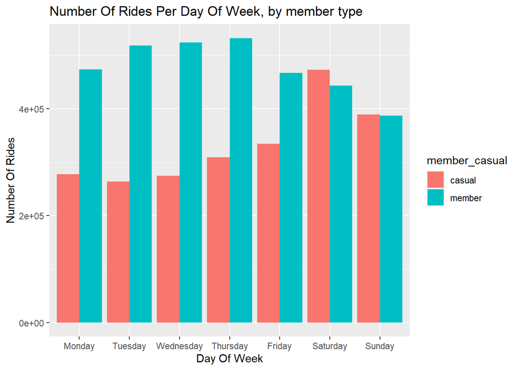

```r
ggplot(graph_data_weekly,aes(x = day_of_week, y = number_of_rides, fill = member_casual)) +
  labs(title = "Number Of Rides Per Day Of Week, by member type", x = "Day Of Week", y = "Number Of Rides") +
  geom_col(position = "dodge")
```

### Graphs for month

```r
tripdata_2022_v3$month <- ordered(tripdata_2022_v3$month,
levels = c("Jan", "Feb", "Mar", "Apr", "May", "Jun","Jul", "Aug", "Sep", "Oct", "Nov", "Dec"))
graph_data_monthly <- tripdata_2022_v3 %>%
  group_by(member_casual, month) %>%
  summarise(number_of_rides = n(), average_duration = mean(ride_length)) %>%
  arrange(member_casual, month)
```

#### Average ride length for month

```
## Defaulting to continuous.
```

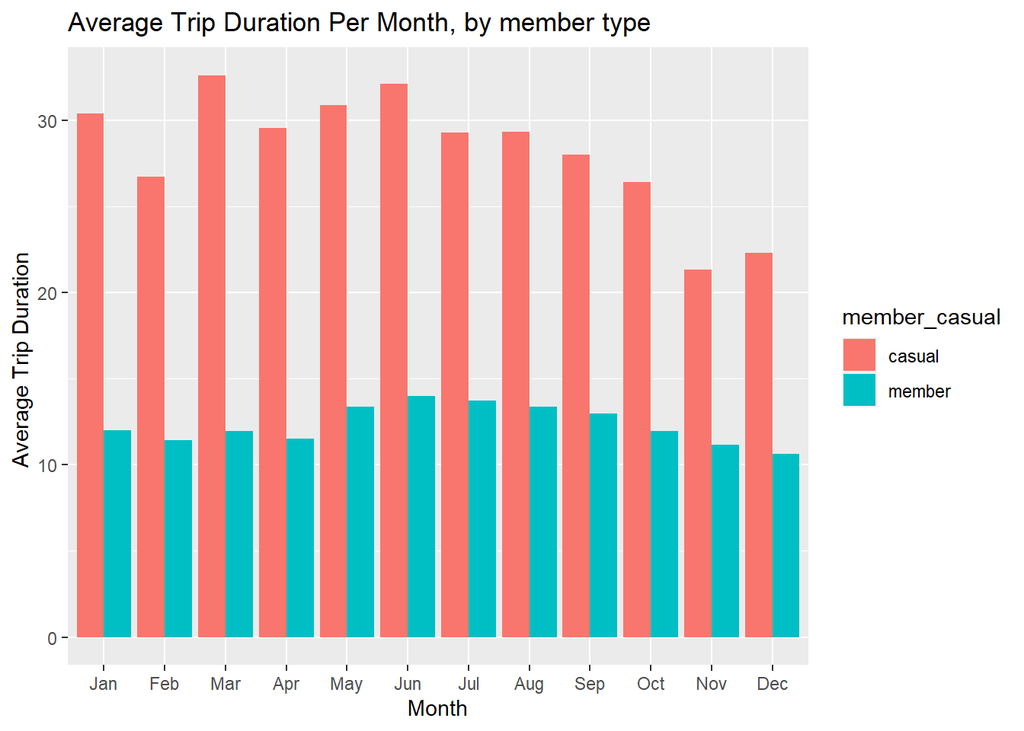

```r
ggplot(graph_data_monthly,aes(x = month, y = average_duration, fill = member_casual)) +
  labs(title = "Average Trip Duration Per Month, by member type", x = "Month", y = "Average Trip Duration ") +
  geom_col(position = "dodge")
```

#### Total rides for month

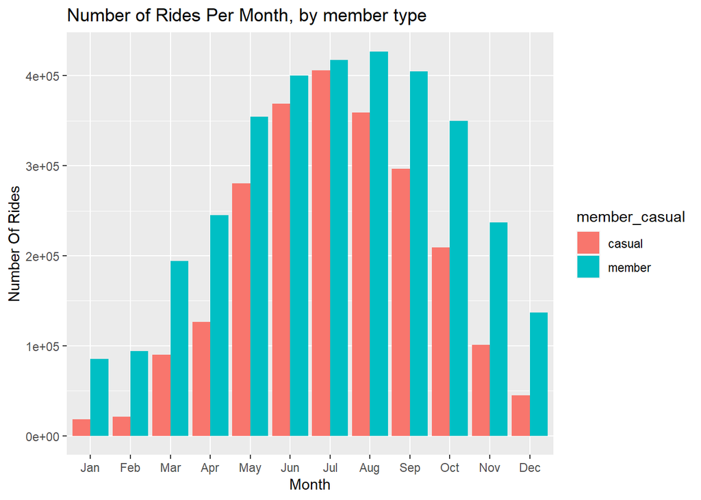

```r
ggplot(graph_data_monthly,aes(x = month, y = number_of_rides, fill = member_casual)) +
  labs(title = "Number of Rides Per Month, by member type", x = "Month", y = "Number Of Rides" ) +
  geom_col(position = "dodge")
```

### Number of rides vs Average duration, per day

```r
twovargraph <- tripdata_2022_v3 %>%
  group_by(date) %>%
  summarise(number_of_rides = n(), average_duration = mean(ride_length)) %>%
  arrange(date)
```

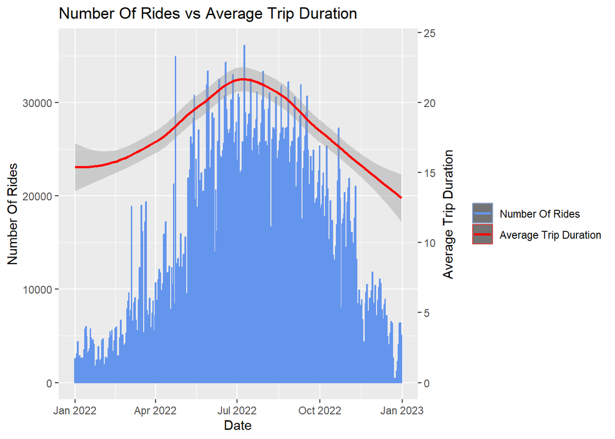

```r
ggplot(twovargraph, aes(x = date)) +
  labs(title = "Number Of Rides vs Average Trip Duration", x = "Date") +
  geom_col(aes(y = number_of_rides, color = "Number Of Rides")) +
  geom_smooth(aes(y = average_duration*1500, color = "Average Trip Duration")) +
  scale_color_manual("", breaks = c("Number Of Rides", "Average Trip Duration"),
                     values = c("Number Of Rides" = "cornflowerblue", "Average Trip Duration" = "red")) +
  scale_y_continuous(
    name = "Number Of Rides" ,
    sec.axis = sec_axis(~./1500, name = "Average Trip Duration")) +
  theme(axis.title.y.right = element_text(angle = 90))
```

## Act

#### **Guiding questions**

- **What is your final conclusion based on your analysis?**

  Casual riders currently have longer trip durations on average but have less total rides than members.
- **How could your team and business apply your insights?**

  Create a marketing campaign targeting casual riders that would highlight the benefits of becoming a member, such as potential cost savings over longer trips.
- **What next steps would you or your stakeholders take based on your findings?**

  Look into the demographics of the casuals, and their most popular stations to help with marketing strategies.
- **Is there additional data you could use to expand on your findings?**

  Additional data could be demographics and financial data on the riders to see if there are additional trends that can be identified that would help with marketing strategy.

##### **Credit**

M.Maguire’s work on the Google Data Analytics Capstone - Case study 1 for 2020 was used as a general outline on how to clean the code and generate appropriate graphs.

Title: Google Data Analytics Capstone - Case Study 1

Author: M. Maguire

Date: Nov 24, 2021

Availability:[Kaggle link](https://www.kaggle.com/code/mmaguire/google-data-analytics-capstone-case-study-1)